# Self-Driving Car Engineer Nanodegree

#### Code Cell 31: Code to load and preprocess images selected from the internet and generate a noise sample too

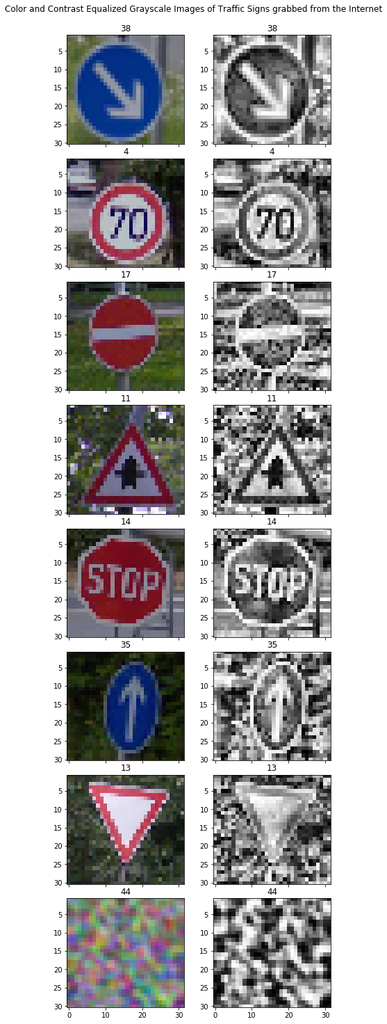

```
All pickled up
```

```python
### Load the images
import numpy as np
import cv2
import skimage as sk
from skimage import io
from skimage import color
import matplotlib.pyplot as plt
import pickle

# images of signs taken from screengrabs on Google streetview
# in Hanover Germany and scaled to 32x32
imgnames = np.array(
           ['./examples/TestSamples/32x32/keepright32x32.png',
            './examples/TestSamples/32x32/Limit70_32x32.png',
            './examples/TestSamples/32x32/noentry_32x32.png',
            './examples/TestSamples/32x32/row_nxt_intersection32x32.png',
            './examples/TestSamples/32x32/Stop32x32.png',
            './examples/TestSamples/32x32/Straightahead32x32.png',
            './examples/TestSamples/32x32/yield32x32.png'])


y_internet = np.array([38,4,17,11,14,35,13,44])

new_imgs = []
fig1, ax1 = plt.subplots(ncols=2, nrows=len(imgnames)+1, figsize=(6,20), frameon=True, squeeze=True, sharex='all')
fig1.suptitle("Color and Contrast Equalized Grayscale Images of Traffic Signs grabbed from the Internet",x=0.5,y=1.02)
fig1.tight_layout()
for i in range(len(imgnames)):
    img = cv2.imread(imgnames[i]) #caution cv2 loads as BGR
    img = img[...,::-1] #convert from BGR to RGB
    new_imgs.append(img)
    #print(np.array(new_imgs).shape)
    ax1[i][0].imshow(img)
    ax1[i][0].set_title(y_internet[i])

#Add an image of random background noise
graynoize = np.random.randint(256, size=(32,32,3), dtype='uint8')
graynoize = cv2.GaussianBlur(graynoize,(3,3),0)
new_imgs.append(graynoize)
np.append(y_internet,44)
ax1[i+1][0].imshow(graynoize)
ax1[i+1][0].set_title(y_internet[i+1])

#print(np.array(new_imgs).shape)
new_imgs = np.asarray(new_imgs)

#Preprocess the data for use in the model
X_internet = []
for i in range(len(new_imgs)):
    img = np.asarray(new_imgs[i])
    cl1, cl1r = imagepipeline(img)
    img = (cl1r-np.mean(cl1r))/np.std(cl1r)
    X_internet.append(np.asfarray(img,dtype='float'))
    ax1[i][1].imshow(img.reshape(32,32), cmap='gray')
    ax1[i][1].set_title(y_internet[i])
plt.show()

out_set ={}
out_set['features'] = X_internet
out_set['labels'] = y_internet

#Pickle up the data
#color images
with open('./examples/TestSamples/32x32/new_imgdata.p', 'wb') as f:
    pickle.dump(new_imgs,f)
    f.close()

#grayscale normalized img data
with open('./examples/TestSamples/32x32/new_gimgdata.p', 'wb') as f:
    pickle.dump(out_set,f)
    f.close()

print("All pickled up")
```

Let's try these images in the model.

#### Code Cell 32: Code to return the top 5 predictions for each image along with the certainties it had for each choice on the internet images.

```
INFO:tensorflow:Restoring parameters from ./traffic_model/MSlenet3
```

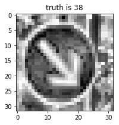

```
AIs ordered choices:   [38 34 12  5 13]
AIs ordered certainty: [ 1.000  0.000  0.000  0.000  0.000]
AI picked correctly!
```

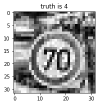

```
AIs ordered choices:   [4 0 1 8 2]
AIs ordered certainty: [ 1.000  0.000  0.000  0.000  0.000]
AI picked correctly!
```

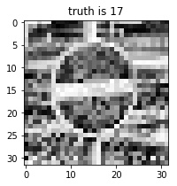

```
AIs ordered choices:   [17 14 13 12 33]
AIs ordered certainty: [ 0.996  0.003  0.001  0.000  0.000]
AI picked correctly!
```

[figure not shown]

```
AIs ordered choices:   [11 30 27 12 29]
AIs ordered certainty: [ 1.000  0.000  0.000  0.000  0.000]
AI picked correctly!
```

[figure not shown]

```
AIs ordered choices:   [14  1  2  8 12]
AIs ordered certainty: [ 1.000  0.000  0.000  0.000  0.000]
AI picked correctly!
```

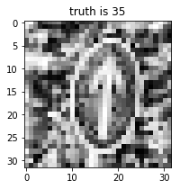

```
AIs ordered choices:   [35 18 26  3 37]
AIs ordered certainty: [ 0.942  0.047  0.004  0.003  0.003]
AI picked correctly!
```

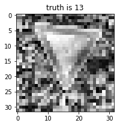

```
AIs ordered choices:   [13 26 27 28 18]
AIs ordered certainty: [ 0.999  0.001  0.001  0.000  0.000]
AI picked correctly!
```

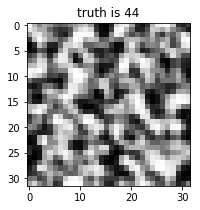

```
AIs ordered choices:   [40 11 27 26 12]
AIs ordered certainty: [ 0.279  0.216  0.189  0.104  0.096]
AI chose incorrectly

Trained model correctly identified 7 of 7 signs at a rate of 100.0% (Random noise image not included in stat)
```

```python
import pickle
import numpy as np
import tensorflow as tf

with open('./examples/TestSamples/32x32/new_gimgdata.p', 'rb') as f:
    in_set = pickle.load(f)
    f.close()

X_internet, y_internet = in_set['features'], in_set['labels']

with tf.Session(config=config) as sess:
    sess.run(tf.global_variables_initializer())#??
    saver.restore(sess, './traffic_model/MSlenet3')
    softmaxProb = sess.run(softmax, feed_dict={x: X_internet, keep_prob: 1.0})
    (top5cert, top5picks) = sess.run(tf.nn.top_k(tf.constant(softmaxProb), k=5))
    np.set_printoptions(formatter={'float': '{: 0.3f}'.format})
    rightchoice = 0
    for i in range(len(X_internet)):
        plot_image(X_internet[i].reshape(32,32),"truth is {}".format(y_internet[i]))
        print("AIs ordered choices:   {}".format(top5picks[i]))
        print("AIs ordered certainty: {}".format(top5cert[i]))
        if top5picks[i][0] == y_internet[i]:
            print("AI picked correctly!")
            rightchoice +=1
        else:
            print("AI chose incorrectly")
        print()
        sess.close()

print("Trained model correctly identified {} of {} signs at a rate of {}% (Random noise image not included in stat)"
      .format(rightchoice, len(y_internet)-1, (rightchoice)*100/(len(y_internet)-1)))
```

The model was able to guess the class of all the images correctly. They were generally fairly good samples, and the model had high certainty for them. The model did not have produce a good match for the noise image, with all guesses having less than 0.3 certainty.

We can now look at how well the model performed for each class of image by examining the Confusion Matrix and Precision, Recall, and F1-Score. We will check these indices on the test set.

#### Code Cell 33: Code to generate a confusion matrix (graphical and HTML table)

```
Confusion matrix:
```

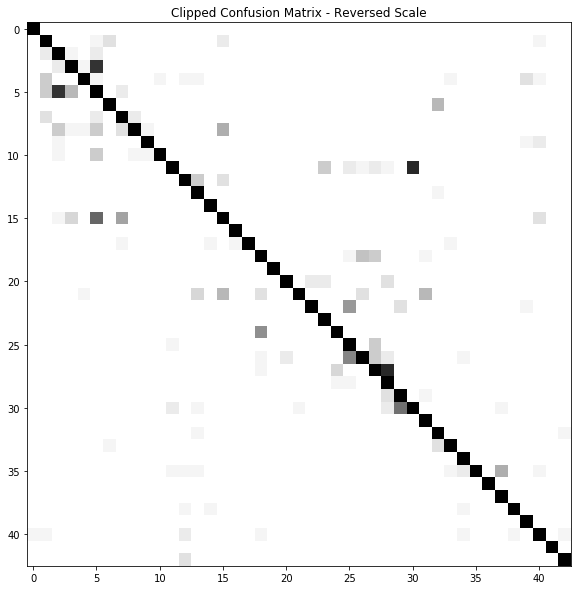

|  | 0 | 1 | 2 | 3 | 4 | 5 | 6 | 7 | 8 | 9 | 10 | 11 | 12 | 13 | 14 | 15 | 16 | 17 | 18 | 19 | 20 | 21 | 22 | 23 | 24 | 25 | 26 | 27 | 28 | … |
| --- | --- | --- | --- | --- | --- | --- | --- | --- | --- | --- | --- | --- | --- | --- | --- | --- | --- | --- | --- | --- | --- | --- | --- | --- | --- | --- | --- | --- | --- | --- |
| 0 | 60 | 0 | 0 | 0 | 0 | 0 | 0 | 0 | 0 | 0 | 0 | 0 | 0 | 0 | 0 | 0 | 0 | 0 | 0 | 0 | 0 | 0 | 0 | 0 | 0 | 0 | 0 | 0 | 0 | … |
| 1 | 0 | 713 | 0 | 0 | 0 | 1 | 3 | 0 | 0 | 0 | 0 | 0 | 0 | 0 | 0 | 2 | 0 | 0 | 0 | 0 | 0 | 0 | 0 | 0 | 0 | 0 | 0 | 0 | 0 | … |
| 2 | 0 | 2 | 745 | 1 | 0 | 2 | 0 | 0 | 0 | 0 | 0 | 0 | 0 | 0 | 0 | 0 | 0 | 0 | 0 | 0 | 0 | 0 | 0 | 0 | 0 | 0 | 0 | 0 | 0 | … |
| 3 | 0 | 0 | 2 | 427 | 1 | 20 | 0 | 0 | 0 | 0 | 0 | 0 | 0 | 0 | 0 | 0 | 0 | 0 | 0 | 0 | 0 | 0 | 0 | 0 | 0 | 0 | 0 | 0 | 0 | … |
| 4 | 0 | 5 | 0 | 0 | 646 | 1 | 0 | 0 | 0 | 0 | 1 | 0 | 1 | 1 | 0 | 0 | 0 | 0 | 0 | 0 | 0 | 0 | 0 | 0 | 0 | 0 | 0 | 0 | 0 | … |
| 5 | 0 | 5 | 20 | 7 | 0 | 596 | 0 | 2 | 0 | 0 | 0 | 0 | 0 | 0 | 0 | 0 | 0 | 0 | 0 | 0 | 0 | 0 | 0 | 0 | 0 | 0 | 0 | 0 | 0 | … |
| 6 | 0 | 0 | 0 | 0 | 0 | 0 | 143 | 0 | 0 | 0 | 0 | 0 | 0 | 0 | 0 | 0 | 0 | 0 | 0 | 0 | 0 | 0 | 0 | 0 | 0 | 0 | 0 | 0 | 0 | … |
| 7 | 0 | 3 | 0 | 0 | 0 | 2 | 0 | 443 | 2 | 0 | 0 | 0 | 0 | 0 | 0 | 0 | 0 | 0 | 0 | 0 | 0 | 0 | 0 | 0 | 0 | 0 | 0 | 0 | 0 | … |
| 8 | 0 | 0 | 5 | 1 | 1 | 5 | 0 | 3 | 426 | 1 | 0 | 0 | 0 | 0 | 0 | 8 | 0 | 0 | 0 | 0 | 0 | 0 | 0 | 0 | 0 | 0 | 0 | 0 | 0 | … |
| 9 | 0 | 0 | 1 | 0 | 0 | 0 | 0 | 0 | 0 | 476 | 0 | 0 | 0 | 0 | 0 | 0 | 0 | 0 | 0 | 0 | 0 | 0 | 0 | 0 | 0 | 0 | 0 | 0 | 0 | … |
| 10 | 0 | 0 | 1 | 0 | 0 | 5 | 0 | 0 | 1 | 1 | 652 | 0 | 0 | 0 | 0 | 0 | 0 | 0 | 0 | 0 | 0 | 0 | 0 | 0 | 0 | 0 | 0 | 0 | 0 | … |
| 11 | 0 | 0 | 0 | 0 | 0 | 0 | 0 | 0 | 0 | 0 | 0 | 388 | 0 | 0 | 0 | 0 | 0 | 0 | 0 | 0 | 0 | 0 | 0 | 5 | 0 | 2 | 1 | 2 | 1 | … |
| 12 | 0 | 0 | 0 | 0 | 0 | 0 | 0 | 0 | 0 | 0 | 0 | 0 | 682 | 5 | 0 | 3 | 0 | 0 | 0 | 0 | 0 | 0 | 0 | 0 | 0 | 0 | 0 | 0 | 0 | … |
| 13 | 0 | 0 | 0 | 0 | 0 | 0 | 0 | 0 | 0 | 0 | 0 | 0 | 0 | 719 | 0 | 0 | 0 | 0 | 0 | 0 | 0 | 0 | 0 | 0 | 0 | 0 | 0 | 0 | 0 | … |
| 14 | 0 | 0 | 0 | 0 | 0 | 0 | 0 | 0 | 0 | 0 | 0 | 0 | 0 | 0 | 270 | 0 | 0 | 0 | 0 | 0 | 0 | 0 | 0 | 0 | 0 | 0 | 0 | 0 | 0 | … |
| 15 | 0 | 0 | 1 | 4 | 0 | 15 | 0 | 9 | 0 | 0 | 0 | 0 | 0 | 0 | 0 | 178 | 0 | 0 | 0 | 0 | 0 | 0 | 0 | 0 | 0 | 0 | 0 | 0 | 0 | … |
| 16 | 0 | 0 | 0 | 0 | 0 | 0 | 0 | 0 | 0 | 0 | 0 | 0 | 0 | 0 | 0 | 0 | 150 | 0 | 0 | 0 | 0 | 0 | 0 | 0 | 0 | 0 | 0 | 0 | 0 | … |
| 17 | 0 | 0 | 0 | 0 | 0 | 0 | 0 | 1 | 0 | 0 | 0 | 0 | 0 | 0 | 1 | 0 | 1 | 356 | 0 | 0 | 0 | 0 | 0 | 0 | 0 | 0 | 0 | 0 | 0 | … |
| 18 | 0 | 0 | 0 | 0 | 0 | 0 | 0 | 0 | 0 | 0 | 0 | 0 | 0 | 0 | 0 | 0 | 0 | 0 | 377 | 0 | 0 | 0 | 0 | 0 | 0 | 1 | 6 | 5 | 0 | … |
| 19 | 0 | 0 | 0 | 0 | 0 | 0 | 0 | 0 | 0 | 0 | 0 | 0 | 0 | 0 | 0 | 0 | 0 | 0 | 0 | 60 | 0 | 0 | 0 | 0 | 0 | 0 | 0 | 0 | 0 | … |
| 20 | 0 | 0 | 0 | 0 | 0 | 0 | 0 | 0 | 0 | 0 | 0 | 0 | 0 | 0 | 0 | 0 | 0 | 0 | 0 | 0 | 83 | 0 | 2 | 2 | 0 | 0 | 0 | 0 | 3 | … |
| 21 | 0 | 0 | 0 | 0 | 1 | 0 | 0 | 0 | 0 | 0 | 0 | 0 | 0 | 4 | 0 | 7 | 0 | 0 | 3 | 0 | 0 | 65 | 0 | 0 | 0 | 0 | 3 | 0 | 0 | … |
| 22 | 0 | 0 | 0 | 0 | 0 | 0 | 0 | 0 | 0 | 0 | 0 | 0 | 0 | 0 | 0 | 0 | 0 | 0 | 0 | 0 | 0 | 0 | 106 | 0 | 0 | 10 | 0 | 0 | 0 | … |
| 23 | 0 | 0 | 0 | 0 | 0 | 0 | 0 | 0 | 0 | 0 | 0 | 0 | 0 | 0 | 0 | 0 | 0 | 0 | 0 | 0 | 0 | 0 | 0 | 150 | 0 | 0 | 0 | 0 | 0 | … |
| 24 | 0 | 0 | 0 | 0 | 0 | 0 | 0 | 0 | 0 | 0 | 0 | 0 | 0 | 0 | 0 | 0 | 0 | 0 | 11 | 0 | 0 | 0 | 0 | 0 | 79 | 0 | 0 | 0 | 0 | … |
| 25 | 0 | 0 | 0 | 0 | 0 | 0 | 0 | 0 | 0 | 0 | 0 | 1 | 0 | 0 | 0 | 0 | 0 | 0 | 0 | 0 | 0 | 0 | 0 | 0 | 0 | 474 | 0 | 5 | 0 | … |
| 26 | 0 | 0 | 0 | 0 | 0 | 0 | 0 | 0 | 0 | 0 | 0 | 0 | 0 | 0 | 0 | 0 | 0 | 0 | 1 | 0 | 2 | 0 | 0 | 0 | 0 | 12 | 157 | 5 | 2 | … |
| 27 | 0 | 0 | 0 | 0 | 0 | 0 | 0 | 0 | 0 | 0 | 0 | 0 | 0 | 0 | 0 | 0 | 0 | 0 | 1 | 0 | 0 | 0 | 0 | 0 | 4 | 0 | 0 | 34 | 21 | … |
| 28 | 0 | 0 | 0 | 0 | 0 | 0 | 0 | 0 | 0 | 0 | 0 | 0 | 0 | 0 | 0 | 0 | 0 | 0 | 0 | 0 | 0 | 0 | 0 | 0 | 1 | 1 | 0 | 0 | 148 | … |
| 29 | 0 | 0 | 0 | 0 | 0 | 0 | 0 | 0 | 0 | 0 | 0 | 0 | 0 | 0 | 0 | 0 | 0 | 0 | 0 | 0 | 0 | 0 | 0 | 0 | 0 | 0 | 0 | 0 | 3 | … |
| 30 | 0 | 0 | 0 | 0 | 0 | 0 | 0 | 0 | 0 | 0 | 0 | 2 | 0 | 1 | 0 | 0 | 0 | 0 | 0 | 0 | 0 | 1 | 0 | 0 | 0 | 0 | 0 | 0 | 2 | … |
| 31 | 0 | 0 | 0 | 0 | 0 | 0 | 0 | 0 | 0 | 0 | 0 | 0 | 0 | 0 | 0 | 0 | 0 | 0 | 0 | 0 | 0 | 0 | 0 | 0 | 0 | 0 | 0 | 0 | 0 | … |
| 32 | 0 | 0 | 0 | 0 | 0 | 0 | 0 | 0 | 0 | 0 | 0 | 0 | 0 | 1 | 0 | 0 | 0 | 0 | 0 | 0 | 0 | 0 | 0 | 0 | 0 | 0 | 0 | 0 | 0 | … |
| 33 | 0 | 0 | 0 | 0 | 0 | 0 | 1 | 0 | 0 | 0 | 0 | 0 | 0 | 0 | 0 | 0 | 0 | 0 | 0 | 0 | 0 | 0 | 0 | 0 | 0 | 0 | 0 | 0 | 0 | … |
| 34 | 0 | 0 | 0 | 0 | 0 | 0 | 0 | 0 | 0 | 0 | 0 | 0 | 0 | 0 | 0 | 0 | 0 | 0 | 0 | 0 | 0 | 0 | 0 | 0 | 0 | 0 | 0 | 0 | 0 | … |
| 35 | 0 | 0 | 0 | 0 | 0 | 0 | 0 | 0 | 0 | 0 | 0 | 1 | 1 | 1 | 0 | 0 | 0 | 0 | 0 | 0 | 0 | 0 | 0 | 0 | 0 | 0 | 0 | 0 | 0 | … |
| 36 | 0 | 0 | 0 | 0 | 0 | 0 | 0 | 0 | 0 | 0 | 0 | 0 | 0 | 0 | 0 | 0 | 0 | 0 | 0 | 0 | 0 | 0 | 0 | 0 | 0 | 0 | 0 | 0 | 0 | … |
| 37 | 0 | 0 | 0 | 0 | 0 | 0 | 0 | 0 | 0 | 0 | 0 | 0 | 0 | 0 | 0 | 0 | 0 | 0 | 0 | 0 | 0 | 0 | 0 | 0 | 0 | 0 | 0 | 0 | 0 | … |
| 38 | 0 | 0 | 0 | 0 | 0 | 0 | 0 | 0 | 0 | 0 | 0 | 0 | 1 | 0 | 1 | 0 | 0 | 0 | 0 | 0 | 0 | 0 | 0 | 0 | 0 | 0 | 0 | 0 | 0 | … |
| 39 | 0 | 0 | 0 | 0 | 0 | 0 | 0 | 0 | 0 | 0 | 0 | 0 | 0 | 0 | 0 | 0 | 0 | 0 | 0 | 0 | 0 | 0 | 0 | 0 | 0 | 0 | 0 | 0 | 0 | … |
| 40 | 1 | 1 | 0 | 0 | 0 | 0 | 0 | 0 | 0 | 0 | 0 | 0 | 2 | 0 | 0 | 0 | 0 | 0 | 1 | 0 | 0 | 0 | 0 | 0 | 0 | 0 | 0 | 0 | 0 | … |
| 41 | 0 | 0 | 0 | 0 | 0 | 0 | 0 | 0 | 0 | 0 | 0 | 0 | 0 | 0 | 0 | 0 | 0 | 0 | 0 | 0 | 0 | 0 | 0 | 0 | 0 | 0 | 0 | 0 | 0 | … |
| 42 | 0 | 0 | 0 | 0 | 0 | 0 | 0 | 0 | 0 | 0 | 0 | 0 | 3 | 0 | 0 | 0 | 0 | 0 | 0 | 0 | 0 | 0 | 0 | 0 | 0 | 0 | 0 | 0 | 0 | … |

```python
from sklearn.metrics import confusion_matrix
from IPython.display import HTML

print('Confusion matrix:')
c_matrix = confusion_matrix(y_true=y_test, y_pred=test_prediction)
np.set_printoptions(threshold=c_matrix.shape[0] * c_matrix.shape[1] + 1, linewidth=(c_matrix.shape[1] + 2) * 4)
#print(c_matrix)
clipped_c_matrix = -np.clip(c_matrix, 0, 25)+25
plot_image(clipped_c_matrix, 'Clipped Confusion Matrix - Reversed Scale', sizex=10, sizey=10)

index = np.array(['0', '1','2','3','4','5','6','7','8','9',
         '10','11','12','13','14','15','16','17','18','19',
         '20','21','22','23','24','25','26','27','28','29',
         '30','31','32','33','34','35','36','37','38','39',
         '40','41','42'])
df = pd.DataFrame(c_matrix, index=index, columns=index)
HTML(df.to_html())
#print(html)
```

#### Code Cell 34: Code to create a markdown Precision, Recall, and F1-Score report table

```python
from sklearn.metrics import precision_recall_fscore_support
from IPython.display import display_markdown

precision, recall, fscore, support = precision_recall_fscore_support(
      y_true=y_test, y_pred=test_prediction)

s ='| Class | Precision | Recall | F-score | Items | Sign Description |\n'
s +='|:-----:|:---------:|:------:|:-------:|:-------:|:-----|\n'

for i in range(len(index)):
    s += '| {} | {:.1f} | {:.1f} | {:.1f} | {} | {} |\n'.format(
                               index[i], precision[i]*100, recall[i]*100,
                                fscore[i]*100, support[i], signnames[i])

display_markdown(s, raw=True);
```

| Class | Precision | Recall | F-score | Items | Sign Description |
| --- | --- | --- | --- | --- | --- |
| 0 | 98.4 | 100.0 | 99.2 | 60 | Speed limit (20km/h) |
| 1 | 97.8 | 99.0 | 98.4 | 720 | Speed limit (30km/h) |
| 2 | 96.1 | 99.3 | 97.7 | 750 | Speed limit (50km/h) |
| 3 | 97.0 | 94.9 | 96.0 | 450 | Speed limit (60km/h) |
| 4 | 99.5 | 97.9 | 98.7 | 660 | Speed limit (70km/h) |
| 5 | 92.1 | 94.6 | 93.3 | 630 | Speed limit (80km/h) |
| 6 | 97.3 | 95.3 | 96.3 | 150 | End of speed limit (80km/h) |
| 7 | 96.7 | 98.4 | 97.6 | 450 | Speed limit (100km/h) |
| 8 | 99.3 | 94.7 | 96.9 | 450 | Speed limit (120km/h) |
| 9 | 99.6 | 99.2 | 99.4 | 480 | No passing |
| 10 | 99.8 | 98.8 | 99.3 | 660 | No passing for vehicles over 3.5 metric tons |
| 11 | 99.0 | 92.4 | 95.6 | 420 | Right-of-way at the next intersection |
| 12 | 98.8 | 98.8 | 98.8 | 690 | Priority road |
| 13 | 98.2 | 99.9 | 99.0 | 720 | Yield |
| 14 | 99.3 | 100.0 | 99.6 | 270 | Stop |
| 15 | 89.9 | 84.8 | 87.3 | 210 | No vehicles |
| 16 | 99.3 | 100.0 | 99.7 | 150 | Vehicles over 3.5 metric tons prohibited |
| 17 | 100.0 | 98.9 | 99.4 | 360 | No entry |
| 18 | 95.7 | 96.7 | 96.2 | 390 | General caution |
| 19 | 100.0 | 100.0 | 100.0 | 60 | Dangerous curve to the left |
| 20 | 97.6 | 92.2 | 94.9 | 90 | Dangerous curve to the right |
| 21 | 98.5 | 72.2 | 83.3 | 90 | Double curve |
| 22 | 98.1 | 88.3 | 93.0 | 120 | Bumpy road |
| 23 | 95.5 | 100.0 | 97.7 | 150 | Slippery road |
| 24 | 94.0 | 87.8 | 90.8 | 90 | Road narrows on the right |
| 25 | 94.8 | 98.8 | 96.7 | 480 | Road work |
| 26 | 94.0 | 87.2 | 90.5 | 180 | Traffic signals |
| 27 | 66.7 | 56.7 | 61.3 | 60 | Pedestrians |
| 28 | 82.2 | 98.7 | 89.7 | 150 | Children crossing |
| 29 | 83.5 | 95.6 | 89.1 | 90 | Bicycles crossing |
| 30 | 86.0 | 86.0 | 86.0 | 150 | Beware of ice/snow |
| 31 | 96.8 | 100.0 | 98.4 | 270 | Wild animals crossing |
| 32 | 84.1 | 96.7 | 89.9 | 60 | End of all speed and passing limits |
| 33 | 98.6 | 98.1 | 98.3 | 210 | Turn right ahead |
| 34 | 96.0 | 100.0 | 98.0 | 120 | Turn left ahead |
| 35 | 100.0 | 96.2 | 98.0 | 390 | Ahead only |
| 36 | 100.0 | 100.0 | 100.0 | 120 | Go straight or right |
| 37 | 87.0 | 100.0 | 93.0 | 60 | Go straight or left |
| 38 | 99.9 | 99.6 | 99.7 | 690 | Keep right |
| 39 | 94.7 | 100.0 | 97.3 | 90 | Keep left |
| 40 | 91.1 | 91.1 | 91.1 | 90 | Roundabout mandatory |
| 41 | 100.0 | 100.0 | 100.0 | 60 | End of no passing |
| 42 | 97.8 | 96.7 | 97.2 | 90 | End of no passing by vehicles over 3.5 metric tons |

With this model the worst performance is found with class 27 'pedestrians' which has both bad precision and recall and a dismal F1 rating of 61.3 wheras the rest of the scores are generally 90 or higher

#### Code Cell 35: Here is some kludged code to show the response of the model at each of the 2d stages in the model pipeline before everything is flattened.

```python
def plot_activations(sess, X_in, pltver, alllayers=False):
    if alllayers == True:
        L1c = L1conv.eval(feed_dict={x: X_in, keep_prob: 1.0})
        L1c = L1c.reshape(-1, 28, 28, 2 ,8)
        L1c = L1c.transpose(0, 3, 1, 4, 2)
        L1c = L1c.reshape(28*2, 28*8)
        fig = plt.figure('L1 conv {}'.format(pltver), figsize=(6,2))
        plt.axis('off')
        plt.imshow(L1c, cmap='gray')
        fig.suptitle('L1 conv',x=0.5,y=1.0, fontsize=18)
        fig.tight_layout()

        L1e = L1elu.eval(feed_dict={x: X_in, keep_prob: 1.0})
        L1e = L1e.reshape(-1, 28, 28, 2 ,8)
        L1e = L1e.transpose(0, 3, 1, 4, 2)
        L1e = L1e.reshape(28*2, 28*8)
        fig = plt.figure('L1 ELU {}'.format(pltver), figsize=(6,2))
        plt.axis('off')
        plt.imshow(L1e, cmap='gray')
        fig.suptitle('L1 ELU',x=0.5,y=1.0, fontsize=18)
        fig.tight_layout()

    L1mp = L1maxpool.eval(feed_dict={x: X_in, keep_prob: 1.0})
    L1mp = L1mp.reshape(-1, 14, 14, 2 ,8)
    L1mp = L1mp.transpose(0, 3, 1, 4, 2)
    L1mp = L1mp.reshape(14*2, 14*8)
    fig = plt.figure('L1 Max Pool {}'.format(pltver), figsize=(7,3))
    plt.axis('off')
    plt.imshow(L1mp, cmap='gray')
    fig.suptitle('L1 Max Pool',x=0.5,y=1.0, fontsize=18)
    fig.tight_layout()

    if alllayers == True:
        L1amp = L1Amaxpool.eval(feed_dict={x: X_in, keep_prob: 1.0})
        L1amp = L1amp.reshape(-1, 3, 3, 2 ,8)
        L1amp = L1amp.transpose(0, 3, 1, 4, 2)
        L1amp = L1amp.reshape(3*2, 3*8)
        fig = plt.figure('L1A Max Pool {}'.format(pltver), figsize=(6,2))
        plt.axis('off')
        plt.imshow(L1amp, cmap='gray')
        fig.suptitle('L1A Max Pool',x=0.5,y=1.0, fontsize=18)
        fig.tight_layout()

        L2c = L2conv.eval(feed_dict={x: X_in, keep_prob: 1.0})
        L2c = L2c.reshape(-1, 10, 10, 2 ,8)
        L2c = L2c.transpose(0, 3, 1, 4, 2)
        L2c = L2c.reshape(10*2, 10*8)
        fig = plt.figure('L2 conv {}'.format(pltver), figsize=(6,2))
        plt.axis('off')
        plt.imshow(L2c, cmap='gray')
        fig.suptitle('L2 conv',x=0.5,y=1.0, fontsize=18)
        fig.tight_layout()

        L2e = L2elu.eval(feed_dict={x: X_in, keep_prob: 1.0})
        L2e = L2e.reshape(-1, 10, 10, 2 ,8)
        L2e = L2e.transpose(0, 3, 1, 4, 2)
        L2e = L2e.reshape(10*2, 10*8)
        fig = plt.figure('L2 ELU {}'.format(pltver), figsize=(6,2))
        plt.axis('off')
        plt.imshow(L2e, cmap='gray')
        fig.suptitle('L2 ELU',x=0.5,y=1.0, fontsize=18)
        fig.tight_layout()

        L2mp = L2maxpool.eval(feed_dict={x: X_in, keep_prob: 1.0})
        L2mp = L2mp.reshape(-1, 5, 5, 2 ,8)
        L2mp = L2mp.transpose(0, 3, 1, 4, 2)
        L2mp = L2mp.reshape(5*2, 5*8)
        fig = plt.figure('L2 Max Pool {}'.format(pltver), figsize=(6,2))
        plt.axis('off')
        plt.imshow(L2mp, cmap='gray')
        fig.suptitle('L2 Max Pool',x=0.5,y=1.0, fontsize=18)
        fig.tight_layout()

    plt.show()
```

We will use the function above to plot the response of the model before and after training to show how the model response changes, and how (hopefully!) the trained model identifies interesting distinctive aspects of the sign

#### Code Cell 36: Display activations for the yield sign.

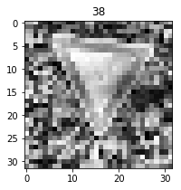

```
Plot of model response prior to training of model.
```

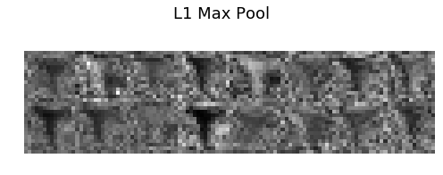

```
=========================================================================

Plot of model response after model has been trained.
INFO:tensorflow:Restoring parameters from ./traffic_model/MSlenet3
```

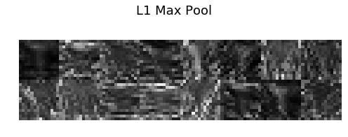

```python
with tf.Session(config=config) as sess:
    plot_image(X_internet[6].reshape(32,32),y_internet[0])
    sess.run(tf.global_variables_initializer())
    print("Plot of model response prior to training of model." )
    plot_activations(sess, X_internet[6:7], 'before0')
    print()
    print("=========================================================================")
    print()
    print("Plot of model response after model has been trained." )
    saver.restore(sess, './traffic_model/MSlenet3')
    plot_activations(sess, X_internet[6:7], 'after0')
    sess.close()
```

With the example of the yield sign we can see that the model has given weight to the horizontal and slanted edges of the triangle after being trained (in the 4th and 5th blocks on the second row), wheras this was not present prior to training.

#### Code Cell 37: Let's see what we can observe with the keep right sign

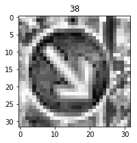

```
Plot of model response prior to training of model.
```

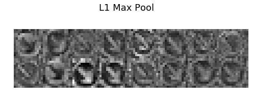

```
=========================================================================

Plot of model response after model has been trained.
INFO:tensorflow:Restoring parameters from ./traffic_model/MSlenet3
```

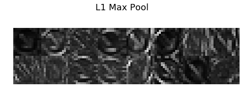

```python
with tf.Session(config=config) as sess:
    plot_image(X_internet[0].reshape(32,32),y_internet[0])
    sess.run(tf.global_variables_initializer())
    print("Plot of model response prior to training of model." )
    plot_activations(sess, X_internet[0:1], 'before1')
    print()
    print("=========================================================================")
    print()
    print("Plot of model response after model has been trained." )
    saver.restore(sess, './traffic_model/MSlenet3')
    plot_activations(sess, X_internet[0:1], 'after1')
    sess.close()
```

Wheras in the initial model the arrow and edge of the sign generally appear to have lower weighting, after being trained, these are the areas that are given highest weights.

#### Code Cell 38: Finally let's see what happens with the noise sample.

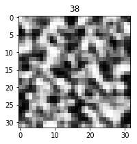

```
Plot of model response prior to training of model.
```

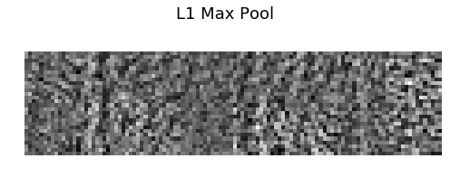

```
=========================================================================

Plot of model response after model has been trained.
INFO:tensorflow:Restoring parameters from ./traffic_model/MSlenet3
```

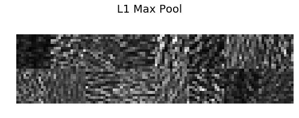

```python
with tf.Session(config=config) as sess:
    plot_image(X_internet[7].reshape(32,32),y_internet[0])
    sess.run(tf.global_variables_initializer())
    print("Plot of model response prior to training of model." )
    plot_activations(sess, X_internet[7:8], 'before2')
    print()
    print("=========================================================================")
    print()
    print("Plot of model response after model has been trained." )
    saver.restore(sess, './traffic_model/MSlenet3')
    plot_activations(sess, X_internet[7:8], 'after2')
    sess.close()
```

It is hard to see any features which could represent a shape with plots from the untrained or trained model, which is a good thing because there is nothing in the image but noise!